# **Non-parametric methods and the caret R package**

# Nonparametric methods

Up to now, we have only dealt with parametric methods, but it is also worth exploring **nonparametric** ones. Non-parametric methods do not make explicit assumptions about the functional form of $f$ (e.g. polynomials). This means to leave data `speak for themselves’ in a free way.

- Such approaches can have a major advantage over parametric approaches: by avoiding the assumption of a particular functional form for $f$, they have the potential to accurately fit a wider range of possible shapes for $f$.
- But non-parametric approaches do suffer from a major disadvantage: since they do not reduce the problem of estimating $f$ to a small number of parameters, a very large number of observations is required in order to obtain an accurate estimate for $f$.

In general, as the flexibility of a method increases, its interpretability decreases.

- [Fig. 2.7 ISLR](http://www-bcf.usc.edu/~gareth/ISL/Chapter2/2.7.pdf)

# k-nearest neighbors

A very simple and quite commonly used method is **k-nearest neighbors** (kNN). The estimate of the function $f$ at each point is obtained as the average of a fixed number of closest observations around that point. This method is called $k$–nearest–neighbors, where $k$ denotes the number of observations averaged by the estimate.

Suppose we want to make a prediction at some $x_0$. Define the neighbourhood $N_k(x_0)$ to be the set of $k$ training observations having values $x_i$ closest to $x_0$ in Euclidean norm $\| x_i - x_0 \|=\sqrt{(x_i - x_0)^\mathsf{T}(x_i - x_0)}$

$$\hat{f}(x_0) = \frac{1}{k}\sum_{i \in N_k(x_0)} y_i$$

As in the case of regression, the number $k$ is a **tuning parameter** related to the complexity of the model. By varying the number of neighbours $k$, we can achieve a wide range of flexibility in the estimated function.

- Small $k$ corresponds to a more flexible fit: the $k$ points are closer to target $x_0$ (low bias), but averages based on a small sample have high variance.
- Large k corresponds to a less flexible fit: it includes points far from $x_0$ (high bias), but have smaller variance.
- Ordinarily, since we are computing a distance, we would want to **center** and **scale** the predictors.

The best value for $k$ depends on how smooth the true function $f$ is, and how noisy $y$ is. We can try different values of $k$ and use e.g. cross-validation to select one value.

Note that kNN is a special case of **local regression** of degree 0, when a nonconstant bandwidth along the x-axis is chosen.

# Exercise

Do the following exercize. Consider the $n=250$ points version of the yesterday-tomorrow data:

- the true $f$, named `f.true250`, is given [here](http://azzalini.stat.unipd.it/Book-DM/f_true.R)
- the true $\sigma$ is $0.01$
- the $x$ values are given by `x = seq(0.5,3,length=250)`
1. Obtain the training set and test set by

```r
set.seed(123)
y = ftrue + rnorm(n, 0,sigmatrue)
ystar = ftrue + rnorm(n, 0,sigmatrue)
train = data.frame(x=x, y=y)
test = data.frame(x=x, y=ystar)
```

2. Install the R package `kknn` and perform kNN with $k=21$ by using the function `kknn(y ~ x, train, test, kernel = "rectangular", k = 21)`

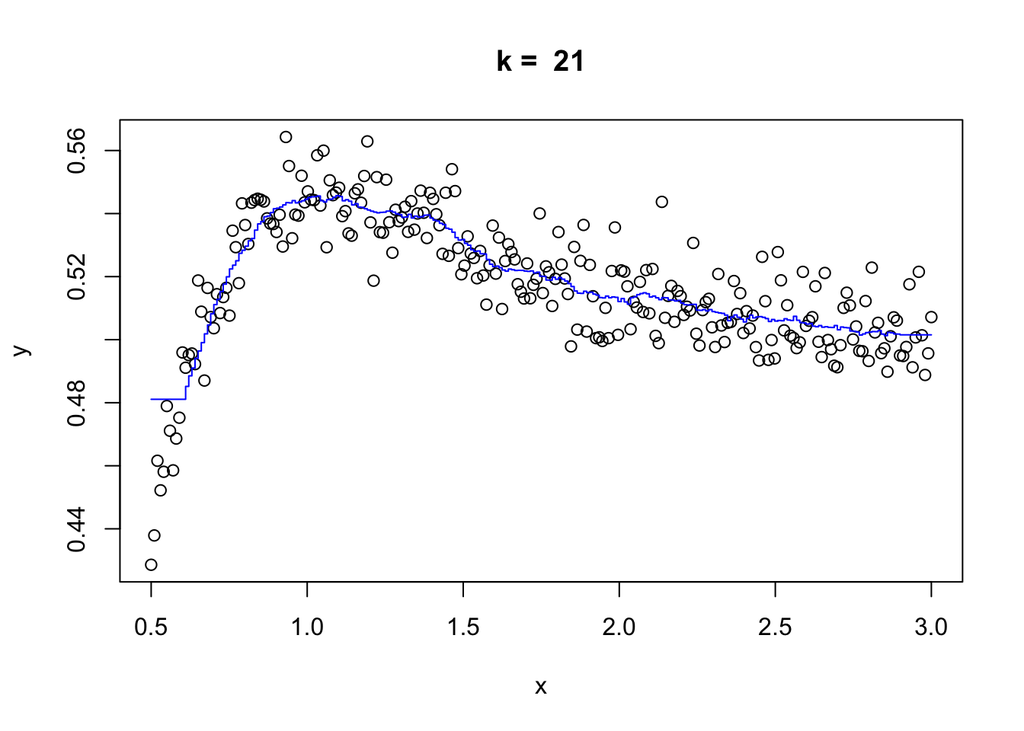

3. Compute MSE.tr and MSE.te for $k=21$

```
[1] "kNN with k = 21 MSE.tr = 0.000111634315005528"
```

```
[1] "kNN with k = 21 MSE.te = 0.000133371260197987"
```

4. Select the tuning parameter $k$ via leave-one-out by the function `train.kknn(y ~ x, train, ks = 1:40, kernel = "rectangular")`

```
[1] "Best k with LOOCV = 7"
```

5. Compute MSE.tr and MSE.te for $k=1,2,\ldots,40$ and find the $k$ corresponding to the minimum MSE.te

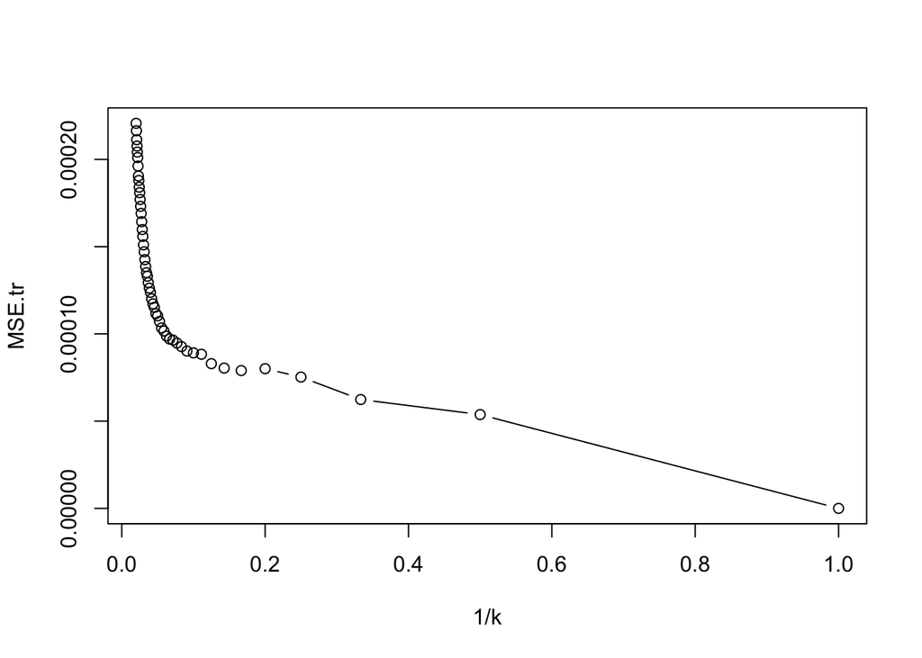

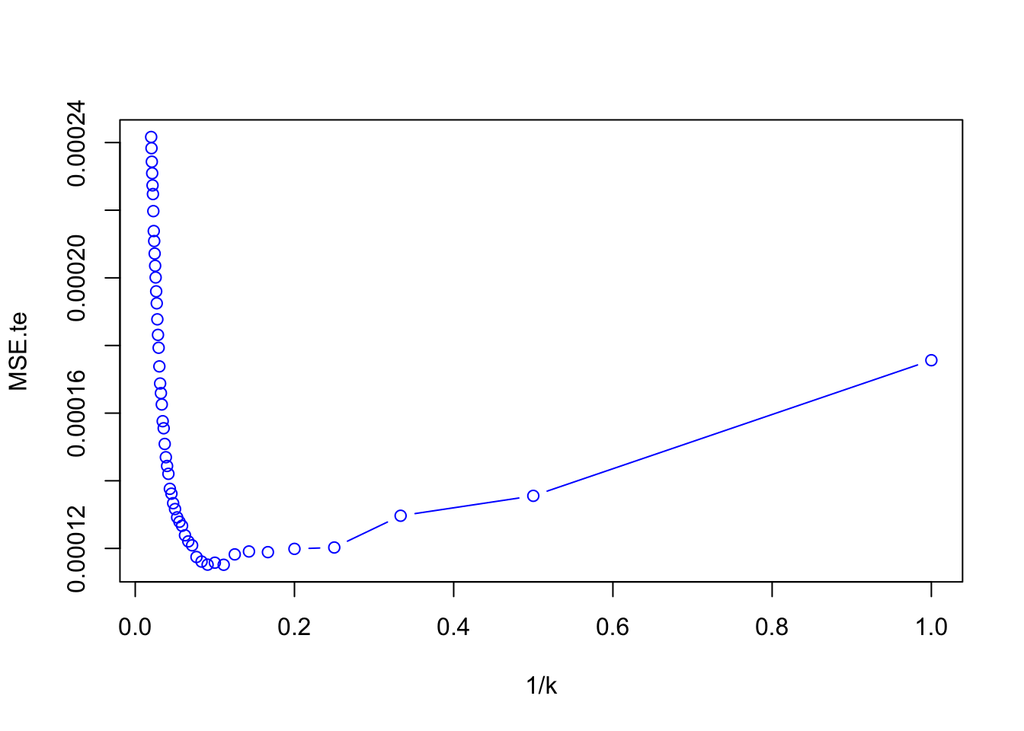

```
[1] 9
```

6. For the fixed-X setting, theoretical results show that for kNN
   $$\mathrm{OptF} = \mathbb{E}(\mathrm{MSE}_{\mathrm{Te}}) - \mathbb{E}(\mathrm{MSE}_{\mathrm{Tr}}) = \frac{2}{n}\sum_{i=1}^{n}\mathbb{C}\mathrm{ov}(y_i,\hat{f}(x_i))= \frac{2\sigma^2}{k}$$
   Find the $k$ corresponding to the minimum
   $$\widehat{\mathrm{Err}} = \mathrm{MSE}_{\mathrm{Tr}} + \frac{2\sigma^2}{k}$$

```
[1] 8
```

7. In the fixed-X setting, theoretical results show that for kNN
   $$\mathrm{Variance}(\hat{f})=\frac{1}{n}\sum_{i=1}^{n}\mathbb{V}\mathrm{ar}[\hat{f}(x_i)] = \frac{\sigma^2}{k}$$
   Remember that the expected value $\mathbb{E}\hat{f}(x_i)$ can be obtained by fitting the kNN model using $y_i = f(x_i)$. This allows to compute the squared bias $[\mathrm{Bias}(\hat{f})]^2= \frac{1}{n}\sum_{i=1}^{n}(\mathbb{E}\hat{f}(x_i) - f(x_i) )^2$. Compute the redubile error $[\mathrm{Bias}(\hat{f})]^2 + \mathrm{Variance}(\hat{f})$ for $k=1,2,\ldots,40$ and find the $k$ that minimize it.

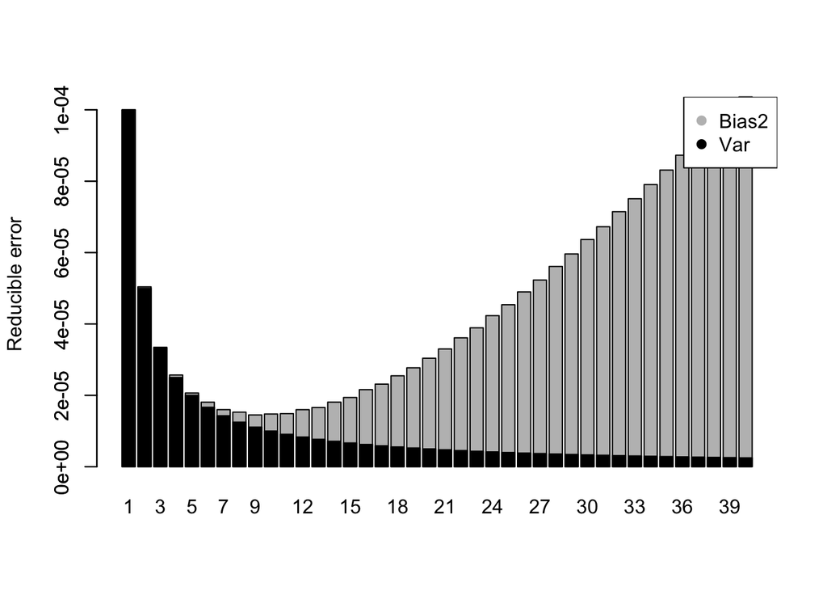

```
[1] 9
```

# The caret package

The [caret](http://topepo.github.io/caret/index.html) package (short for _C_lassification _A_nd _RE_gression _T_raining) is a set of functions that attempt to streamline the process for creating predictive models. The package contains tools for:

- data splitting
- pre-processing
- feature selection
- model tuning using resampling
- variable importance estimation

as well as other functionality.

The package utilizes a number of R packages but tries not to load them all at package start-up. The package “suggests” field includes 76 packages. `caret` loads packages as needed and assumes that they are installed. Install caret using

```r
 install.packages("caret", dependencies = c("Depends", "Suggests"))
```

to ensure that **all** the needed packages are installed.

- The main help pages for the package are at https://topepo.github.io/caret/
- The book [Applied Predictive Modeling](http://appliedpredictivemodeling.com/) can be view as an introduction to the `caret` package.

One of the primary tools in the package is the `train` function which can be used to evaluate, using resampling, the effect of model tuning parameters on performance choose the optimal model across these parameters estimate model performance from a training set. More formally, the **pseudocode** is

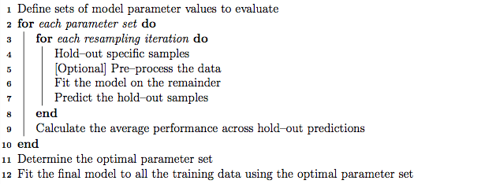

The most basic syntax to do this is:

```r
library(caret)
fit.knn = train(
  y ~ ., train,
  method = "knn")
# result
fit.knn
```

```
k-Nearest Neighbors

250 samples
  1 predictor

No pre-processing
Resampling: Bootstrapped (25 reps)
Summary of sample sizes: 250, 250, 250, 250, 250, 250, ...
Resampling results across tuning parameters:

  k  RMSE        Rsquared   MAE
  5  0.01146809  0.7261602  0.008978840
  7  0.01105863  0.7438812  0.008674320
  9  0.01095533  0.7485859  0.008545349

RMSE was used to select the optimal model using the smallest value.
The final value used for the model was k = 9.
```

- To modify the resampling method, a `trainControl` function is used. The option method controls the type of resampling and defaults to `boot`. Another method, `repeatedcv`, is used to specify repeated $K$-fold cross-validation (and the argument repeats controls the number of repetitions). $K$ is controlled by the number argument and defaults to 10.
- To change the candidate values of the tuning parameter, either of the `tuneLength` or `tuneGrid` arguments can be used. The train function can generate a candidate set of parameter values and the tuneLength argument controls how many are evaluated. The `tuneGrid` argument is used when specific values are desired.

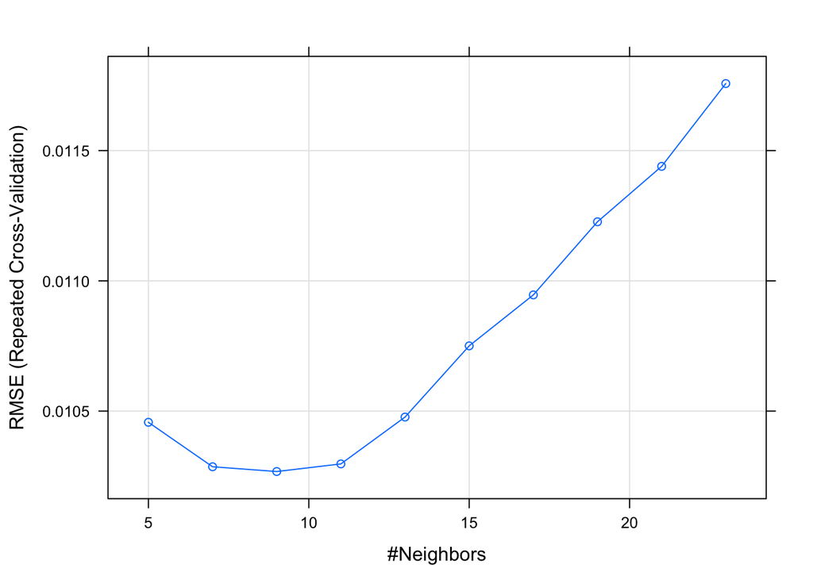

```r
rcv <- trainControl(
  method = "repeatedcv",
  number = 5,
  repeats = 2
)
fit.knn = train(
  y ~ ., train,
  method = "knn",
  trControl=rcv,
  tuneLength = 10)
plot(fit.knn)
```

```r
fit.knn$bestTune
```

```
  k
3 9
```

Compare to polynomial regression of degree $d=6$ (which is the best choice for this example)

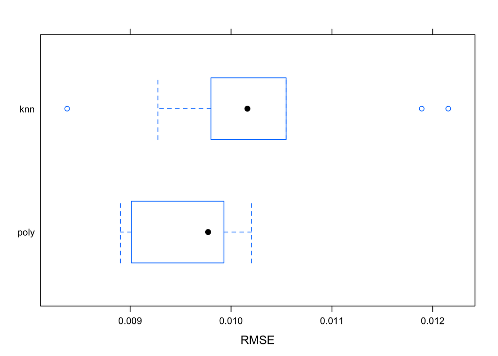

```r
fit.poly = train(
  y ~ poly(x,degree=6), train,
  method = "lm",
  trControl=rcv)
models = list(
    knn=fit.knn,
    poly=fit.poly
  )
resamps = resamples(models)
bwplot(resamps, metric = "RMSE")
```

```r
yhats = predict(models, newdata=test)
lapply(yhats, function(yhat) sqrt( mean( (yhat - test$y)^2) ) )
```

```
$knn
[1] 0.01073157

$poly
[1] 0.01008743
```